# Understanding Employee Turnover: A Statistical and Predictive Analysis of HR Attrition Patterns

Team 4

2025-04-22

## 1 Executive Summary

Employee turnover is a major challenge, not just for HR but for businesses at large. Costs range from 50%–200% of the employee’s annual salary. Through data science, we can predict risk, understand drivers of attrition, and improve retention strategies.

## 2 Project Goals

1. Identify key drivers of attrition
2. Build predictive models
3. Segment employees by attrition risk
4. Recommend HR interventions

## 3 Data Overview

| Age | Attrition | BusinessTravel | DailyRate | Department | DistanceFromHome | Education | EducationField | EmployeeCount | EmployeeNumber | EnvironmentSatisfaction | Gender | HourlyRate | JobInvolvement | JobLevel | JobRole | JobSatisfaction | MaritalStatus | MonthlyIncome | MonthlyRate | NumCompaniesWorked | Over18 | OverTime | PercentSalaryHike | PerformanceRating | RelationshipSatisfaction | StandardHours | StockOptionLevel | TotalWorkingYears | TrainingTimesLastYear | … |
| --- | --- | --- | --- | --- | --- | --- | --- | --- | --- | --- | --- | --- | --- | --- | --- | --- | --- | --- | --- | --- | --- | --- | --- | --- | --- | --- | --- | --- | --- | --- |
| 41 | Yes | Travel_Rarely | 1102 | Sales | 1 | 2 | Life Sciences | 1 | 1 | 2 | Female | 94 | 3 | 2 | Sales Executive | 4 | Single | 5993 | 19479 | 8 | Y | Yes | 11 | 3 | 1 | 80 | 0 | 8 | 0 | … |
| 49 | No | Travel_Frequently | 279 | Research & Development | 8 | 1 | Life Sciences | 1 | 2 | 3 | Male | 61 | 2 | 2 | Research Scientist | 2 | Married | 5130 | 24907 | 1 | Y | No | 23 | 4 | 4 | 80 | 1 | 10 | 3 | … |
| 37 | Yes | Travel_Rarely | 1373 | Research & Development | 2 | 2 | Other | 1 | 4 | 4 | Male | 92 | 2 | 1 | Laboratory Technician | 3 | Single | 2090 | 2396 | 6 | Y | Yes | 15 | 3 | 2 | 80 | 0 | 7 | 3 | … |
| 33 | No | Travel_Frequently | 1392 | Research & Development | 3 | 4 | Life Sciences | 1 | 5 | 4 | Female | 56 | 3 | 1 | Research Scientist | 3 | Married | 2909 | 23159 | 1 | Y | Yes | 11 | 3 | 3 | 80 | 0 | 8 | 3 | … |
| 27 | No | Travel_Rarely | 591 | Research & Development | 2 | 1 | Medical | 1 | 7 | 1 | Male | 40 | 3 | 1 | Laboratory Technician | 2 | Married | 3468 | 16632 | 9 | Y | No | 12 | 3 | 4 | 80 | 1 | 6 | 3 | … |
| 32 | No | Travel_Frequently | 1005 | Research & Development | 2 | 2 | Life Sciences | 1 | 8 | 4 | Male | 79 | 3 | 1 | Laboratory Technician | 4 | Single | 3068 | 11864 | 0 | Y | No | 13 | 3 | 3 | 80 | 0 | 8 | 2 | … |

Data Frame Summary

hr

**Dimensions**: 4000 x 35  
**Duplicates**: 0

| **No** | **Variable** | **Stats / Values** | **Freqs (% of Valid)** | **Graph** | **Valid** | **Missing** |
| --- | --- | --- | --- | --- | --- | --- |
| 1 | Age [numeric] | Mean (sd) : 36.8 (9.1) min ≤ med ≤ max: 18 ≤ 35 ≤ 60 IQR (CV) : 13 (0.2) | 43 distinct values |  | 4000 (100.0%) | 0 (0.0%) |
| 2 | Attrition [character] | 1. No 2. Yes | 3350 ( 83.8% ) 650 ( 16.2% ) |  | 4000 (100.0%) | 0 (0.0%) |
| 3 | BusinessTravel [character] | 1. Non-Travel 2. Travel_Frequently 3. Travel_Rarely | 402 ( 10.1% ) 740 ( 18.5% ) 2858 ( 71.4% ) |  | 4000 (100.0%) | 0 (0.0%) |
| 4 | DailyRate [numeric] | Mean (sd) : 802.6 (400.8) min ≤ med ≤ max: 102 ≤ 793 ≤ 1499 IQR (CV) : 687 (0.5) | 1304 distinct values |  | 4000 (100.0%) | 0 (0.0%) |
| 5 | Department [character] | 1. Human Resources 2. Research & Development 3. Sales | 152 ( 3.8% ) 2633 ( 65.8% ) 1215 ( 30.4% ) |  | 4000 (100.0%) | 0 (0.0%) |
| 6 | DistanceFromHome [numeric] | Mean (sd) : 9.3 (8.2) min ≤ med ≤ max: 1 ≤ 7 ≤ 29 IQR (CV) : 12 (0.9) | 29 distinct values |  | 4000 (100.0%) | 0 (0.0%) |
| 7 | Education [numeric] | Mean (sd) : 2.9 (1) min ≤ med ≤ max: 1 ≤ 3 ≤ 5 IQR (CV) : 2 (0.3) | 1 : 476 ( 11.9% ) 2 : 725 ( 18.1% ) 3 : 1595 ( 39.9% ) 4 : 1089 ( 27.2% ) 5 : 115 ( 2.9% ) |  | 4000 (100.0%) | 0 (0.0%) |
| 8 | EducationField [character] | 1. Human Resources 2. Life Sciences 3. Marketing 4. Medical 5. Other 6. Technical Degree | 65 ( 1.6% ) 1680 ( 42.0% ) 428 ( 10.7% ) 1239 ( 31.0% ) 217 ( 5.4% ) 371 ( 9.3% ) |  | 4000 (100.0%) | 0 (0.0%) |
| 9 | EmployeeCount [numeric] | 1 distinct value | 1 : 4000 ( 100.0% ) |  | 4000 (100.0%) | 0 (0.0%) |
| 10 | EmployeeNumber [numeric] | Mean (sd) : 1031.4 (606.7) min ≤ med ≤ max: 1 ≤ 1024.5 ≤ 2068 IQR (CV) : 1079 (0.6) | 1865 distinct values |  | 4000 (100.0%) | 0 (0.0%) |
| 11 | EnvironmentSatisfaction [numeric] | Mean (sd) : 2.7 (1.1) min ≤ med ≤ max: 1 ≤ 3 ≤ 4 IQR (CV) : 2 (0.4) | 1 : 765 ( 19.1% ) 2 : 777 ( 19.4% ) 3 : 1251 ( 31.3% ) 4 : 1207 ( 30.2% ) |  | 4000 (100.0%) | 0 (0.0%) |
| 12 | Gender [character] | 1. Female 2. Male | 1587 ( 39.7% ) 2413 ( 60.3% ) |  | 4000 (100.0%) | 0 (0.0%) |
| 13 | HourlyRate [numeric] | Mean (sd) : 65.6 (20.3) min ≤ med ≤ max: 30 ≤ 66 ≤ 100 IQR (CV) : 35 (0.3) | 71 distinct values |  | 4000 (100.0%) | 0 (0.0%) |
| 14 | JobInvolvement [numeric] | Mean (sd) : 2.7 (0.7) min ≤ med ≤ max: 1 ≤ 3 ≤ 4 IQR (CV) : 1 (0.3) | 1 : 226 ( 5.7% ) 2 : 1003 ( 25.1% ) 3 : 2381 ( 59.5% ) 4 : 390 ( 9.8% ) |  | 4000 (100.0%) | 0 (0.0%) |
| 15 | JobLevel [numeric] | Mean (sd) : 2.1 (1.1) min ≤ med ≤ max: 1 ≤ 2 ≤ 5 IQR (CV) : 2 (0.5) | 1 : 1484 ( 37.1% ) 2 : 1445 ( 36.1% ) 3 : 603 ( 15.1% ) 4 : 298 ( 7.4% ) 5 : 170 ( 4.2% ) |  | 4000 (100.0%) | 0 (0.0%) |
| 16 | JobRole [character] | 1. Healthcare Representative 2. Human Resources 3. Laboratory Technician 4. Manager 5. Manufacturing Director 6. Research Director 7. Research Scientist 8. Sales Executive 9. Sales Representative | 369 ( 9.2% ) 127 ( 3.2% ) 708 ( 17.7% ) 255 ( 6.4% ) 402 ( 10.1% ) 238 ( 5.9% ) 774 ( 19.4% ) 878 ( 22.0% ) 249 ( 6.2% ) |  | 4000 (100.0%) | 0 (0.0%) |
| 17 | JobSatisfaction [numeric] | Mean (sd) : 2.7 (1.1) min ≤ med ≤ max: 1 ≤ 3 ≤ 4 IQR (CV) : 2 (0.4) | 1 : 805 ( 20.1% ) 2 : 752 ( 18.8% ) 3 : 1193 ( 29.8% ) 4 : 1250 ( 31.2% ) |  | 4000 (100.0%) | 0 (0.0%) |
| 18 | MaritalStatus [character] | 1. Divorced 2. Married 3. Single | 876 ( 21.9% ) 1848 ( 46.2% ) 1276 ( 31.9% ) |  | 4000 (100.0%) | 0 (0.0%) |
| 19 | MonthlyIncome [numeric] | Mean (sd) : 6467 (4688.2) min ≤ med ≤ max: 1009 ≤ 4908.5 ≤ 19999 IQR (CV) : 5491.5 (0.7) | 3215 distinct values |  | 4000 (100.0%) | 0 (0.0%) |
| 20 | MonthlyRate [numeric] | Mean (sd) : 14254.7 (7116.6) min ≤ med ≤ max: 2094 ≤ 14282.5 ≤ 26999 IQR (CV) : 12350.8 (0.5) | 3695 distinct values |  | 4000 (100.0%) | 0 (0.0%) |
| 21 | NumCompaniesWorked [numeric] | Mean (sd) : 2.7 (2.5) min ≤ med ≤ max: 0 ≤ 2 ≤ 9 IQR (CV) : 3 (0.9) | 0 : 527 ( 13.2% ) 1 : 1442 ( 36.0% ) 2 : 389 ( 9.7% ) 3 : 431 ( 10.8% ) 4 : 360 ( 9.0% ) 5 : 182 ( 4.6% ) 6 : 191 ( 4.8% ) 7 : 193 ( 4.8% ) 8 : 141 ( 3.5% ) 9 : 144 ( 3.6% ) |  | 4000 (100.0%) | 0 (0.0%) |
| 22 | Over18 [character] | 1. Y | 4000 ( 100.0% ) |  | 4000 (100.0%) | 0 (0.0%) |
| 23 | OverTime [character] | 1. No 2. Yes | 2889 ( 72.2% ) 1111 ( 27.8% ) |  | 4000 (100.0%) | 0 (0.0%) |
| 24 | PercentSalaryHike [numeric] | Mean (sd) : 15.1 (3.6) min ≤ med ≤ max: 11 ≤ 14 ≤ 25 IQR (CV) : 6 (0.2) | 15 distinct values |  | 4000 (100.0%) | 0 (0.0%) |
| 25 | PerformanceRating [numeric] | Min : 3 Mean : 3.1 Max : 4 | 3 : 3427 ( 85.7% ) 4 : 573 ( 14.3% ) |  | 4000 (100.0%) | 0 (0.0%) |
| 26 | RelationshipSatisfaction [numeric] | Mean (sd) : 2.7 (1.1) min ≤ med ≤ max: 1 ≤ 3 ≤ 4 IQR (CV) : 2 (0.4) | 1 : 754 ( 18.9% ) 2 : 816 ( 20.4% ) 3 : 1268 ( 31.7% ) 4 : 1162 ( 29.0% ) |  | 4000 (100.0%) | 0 (0.0%) |
| 27 | StandardHours [numeric] | 1 distinct value | 80 : 4000 ( 100.0% ) |  | 4000 (100.0%) | 0 (0.0%) |
| 28 | StockOptionLevel [numeric] | Mean (sd) : 0.8 (0.9) min ≤ med ≤ max: 0 ≤ 1 ≤ 3 IQR (CV) : 1 (1.1) | 0 : 1732 ( 43.3% ) 1 : 1590 ( 39.8% ) 2 : 451 ( 11.3% ) 3 : 227 ( 5.7% ) |  | 4000 (100.0%) | 0 (0.0%) |
| 29 | TotalWorkingYears [numeric] | Mean (sd) : 11.2 (7.8) min ≤ med ≤ max: 0 ≤ 10 ≤ 40 IQR (CV) : 9 (0.7) | 40 distinct values |  | 4000 (100.0%) | 0 (0.0%) |
| 30 | TrainingTimesLastYear [numeric] | Mean (sd) : 2.8 (1.3) min ≤ med ≤ max: 0 ≤ 3 ≤ 6 IQR (CV) : 1 (0.5) | 0 : 161 ( 4.0% ) 1 : 185 ( 4.6% ) 2 : 1460 ( 36.5% ) 3 : 1324 ( 33.1% ) 4 : 346 ( 8.6% ) 5 : 342 ( 8.6% ) 6 : 182 ( 4.6% ) |  | 4000 (100.0%) | 0 (0.0%) |
| 31 | WorkLifeBalance [numeric] | Mean (sd) : 2.8 (0.7) min ≤ med ≤ max: 1 ≤ 3 ≤ 4 IQR (CV) : 1 (0.3) | 1 : 215 ( 5.4% ) 2 : 937 ( 23.4% ) 3 : 2439 ( 61.0% ) 4 : 409 ( 10.2% ) |  | 4000 (100.0%) | 0 (0.0%) |
| 32 | YearsAtCompany [numeric] | Mean (sd) : 6.9 (6) min ≤ med ≤ max: 0 ≤ 5 ≤ 40 IQR (CV) : 6 (0.9) | 37 distinct values |  | 4000 (100.0%) | 0 (0.0%) |
| 33 | YearsInCurrentRole [numeric] | Mean (sd) : 4.2 (3.7) min ≤ med ≤ max: 0 ≤ 3 ≤ 18 IQR (CV) : 5 (0.9) | 19 distinct values |  | 4000 (100.0%) | 0 (0.0%) |
| 34 | YearsSinceLastPromotion [numeric] | Mean (sd) : 2.1 (3.2) min ≤ med ≤ max: 0 ≤ 1 ≤ 15 IQR (CV) : 2 (1.5) | 16 distinct values |  | 4000 (100.0%) | 0 (0.0%) |
| 35 | YearsWithCurrManager [numeric] | Mean (sd) : 4.1 (3.6) min ≤ med ≤ max: 0 ≤ 3 ≤ 17 IQR (CV) : 5 (0.9) | 18 distinct values |  | 4000 (100.0%) | 0 (0.0%) |

Generated by summarytools 1.1.3 ([R](https://www.r-project.org/) version 4.4.2)  
2025-04-22

## 4 Exploratory Data Analysis

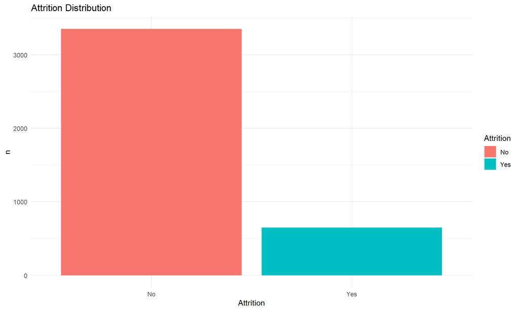

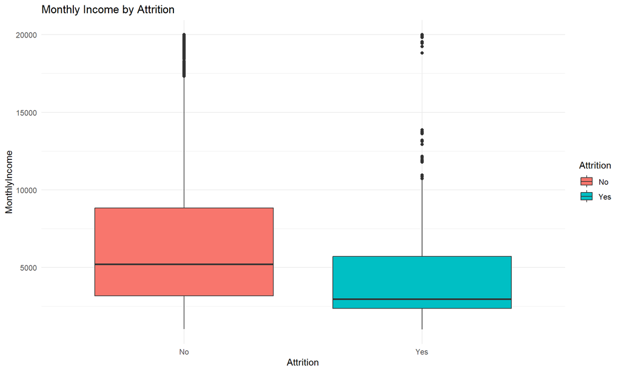

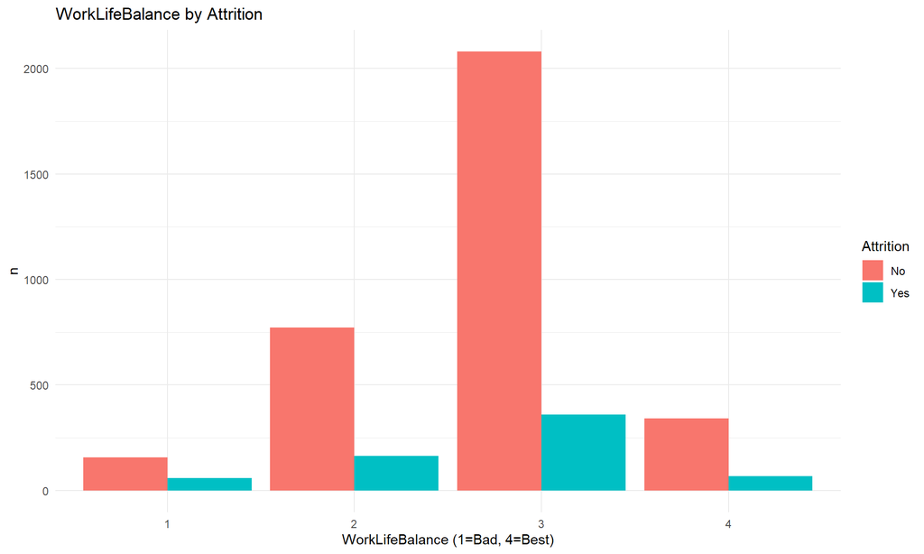

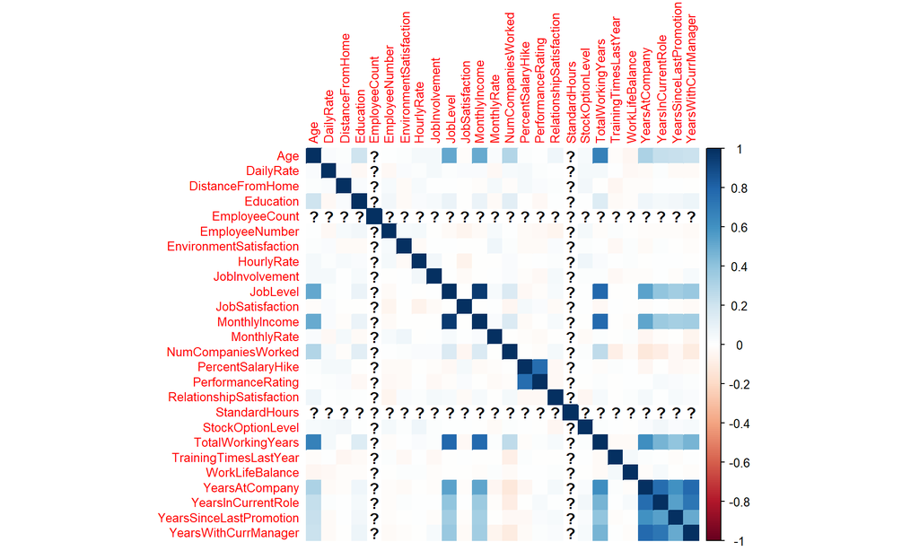

## 5 Hypothesis Testing

### 5.1 Years at Company vs Attrition

```
##
##  Welch Two Sample t-test
##
## data:  YearsAtCompany by Attrition
## t = 11.239, df = 1018.9, p-value < 0.00000000000000022
## alternative hypothesis: true difference in means between group No and group Yes is not equal to 0
## 95 percent confidence interval:
##  2.114537 3.009137
## sample estimates:
##  mean in group No mean in group Yes
##          7.300299          4.738462
```

**Interpretation:** Employees who stayed longer at the company had a significantly lower chance of leaving. Mean difference is ~2.6 years (p < 0.001).

### 5.2 Job Satisfaction vs Attrition

```
##
##  Welch Two Sample t-test
##
## data:  JobSatisfaction by Attrition
## t = 6.954, df = 898.07, p-value = 0.000000000006833
## alternative hypothesis: true difference in means between group No and group Yes is not equal to 0
## 95 percent confidence interval:
##  0.2416856 0.4317472
## sample estimates:
##  mean in group No mean in group Yes
##          2.776716          2.440000
```

**Interpretation:** Employees who left had significantly lower job satisfaction scores on average (p < 0.001).

### 5.3 Environment Satisfaction vs Attrition

```
##
##  Welch Two Sample t-test
##
## data:  EnvironmentSatisfaction by Attrition
## t = 7.1468, df = 876.93, p-value = 0.000000000001869
## alternative hypothesis: true difference in means between group No and group Yes is not equal to 0
## 95 percent confidence interval:
##  0.2535072 0.4454595
## sample estimates:
##  mean in group No mean in group Yes
##          2.781791          2.432308
```

**Interpretation:** Those who stayed reported higher satisfaction with their work environment (p < 0.001).

### 5.4 Monthly Income vs Attrition

```
##
##  Welch Two Sample t-test
##
## data:  MonthlyIncome by Attrition
## t = 13.963, df = 1185.8, p-value < 0.00000000000000022
## alternative hypothesis: true difference in means between group No and group Yes is not equal to 0
## 95 percent confidence interval:
##  1918.073 2545.209
## sample estimates:
##  mean in group No mean in group Yes
##          6829.649          4598.008
```

**Interpretation:** Monthly income was significantly lower for employees who left (p < 0.001).

### 5.5 Business Travel and Attrition

```
##
##  Pearson's Chi-squared test
##
## data:  table_travel
## X-squared = 79.986, df = 2, p-value < 0.00000000000000022
```

**Interpretation:** There is a strong association between frequency of business travel and employee attrition (p < 0.001).

### 5.6 Job Role and Attrition

```
##
##  Pearson's Chi-squared test
##
## data:  table_role
## X-squared = 281.83, df = 8, p-value < 0.00000000000000022
```

**Interpretation:** Certain job roles show significantly higher or lower attrition rates (p < 0.001).

### 5.7 OverTime and Attrition

```
##
##  Pearson's Chi-squared test with Yates' continuity correction
##
## data:  table_overtime
## X-squared = 252.22, df = 1, p-value < 0.00000000000000022
```

**Interpretation:** Employees working overtime had a much higher likelihood of leaving (p < 0.001).

[output not shown]

[output not shown]

[output not shown]

[output not shown]

[output not shown]

[output not shown]

[output not shown]

## 6 Logistic Regression Modeling

### 6.1 Logistic Regression Data Preparation

### 6.2 Logistic Regression

```
##
## Call:
## glm(formula = AttritionBinary ~ ., family = binomial, data = logit_data)
##
## Coefficients:
##                                    Estimate  Std. Error z value
## (Intercept)                      0.94801401  0.31671993   2.993
## MonthlyIncome                   -0.00012530  0.00001574  -7.963
## JobSatisfaction                 -0.34557233  0.04236381  -8.157
## EnvironmentSatisfaction         -0.41932486  0.04432898  -9.459
## OverTimeYes                      1.59795449  0.09880931  16.172
## BusinessTravelTravel_Frequently  1.38600731  0.21170631   6.547
## BusinessTravelTravel_Rarely      0.57188307  0.19822893   2.885
## YearsAtCompany                  -0.06921024  0.01193758  -5.798
## WorkLifeBalance                 -0.29659063  0.06644698  -4.464
##                                             Pr(>|z|)
## (Intercept)                                  0.00276 **
## MonthlyIncome                   0.000000000000001684 ***
## JobSatisfaction                 0.000000000000000343 ***
## EnvironmentSatisfaction         < 0.0000000000000002 ***
## OverTimeYes                     < 0.0000000000000002 ***
## BusinessTravelTravel_Frequently 0.000000000058767342 ***
## BusinessTravelTravel_Rarely                  0.00391 **
## YearsAtCompany                  0.000000006724036643 ***
## WorkLifeBalance                 0.000008060591849622 ***
## ---
## Signif. codes:  0 '***' 0.001 '**' 0.01 '*' 0.05 '.' 0.1 ' ' 1
##
## (Dispersion parameter for binomial family taken to be 1)
##
##     Null deviance: 3550.3  on 3999  degrees of freedom
## Residual deviance: 2881.5  on 3991  degrees of freedom
## AIC: 2899.5
##
## Number of Fisher Scoring iterations: 6
```

### 6.3 Random Forest Classification

```
##
## Call:
##  randomForest(formula = AttritionBinary ~ ., data = logit_data,      ntree = 500, mtry = 3, importance = TRUE)
##                Type of random forest: classification
##                      Number of trees: 500
## No. of variables tried at each split: 3
##
##         OOB estimate of  error rate: 3.7%
## Confusion matrix:
##      0   1 class.error
## 0 3318  32 0.009552239
## 1  116 534 0.178461538
```

### 6.4 Random Forest Variable Importance

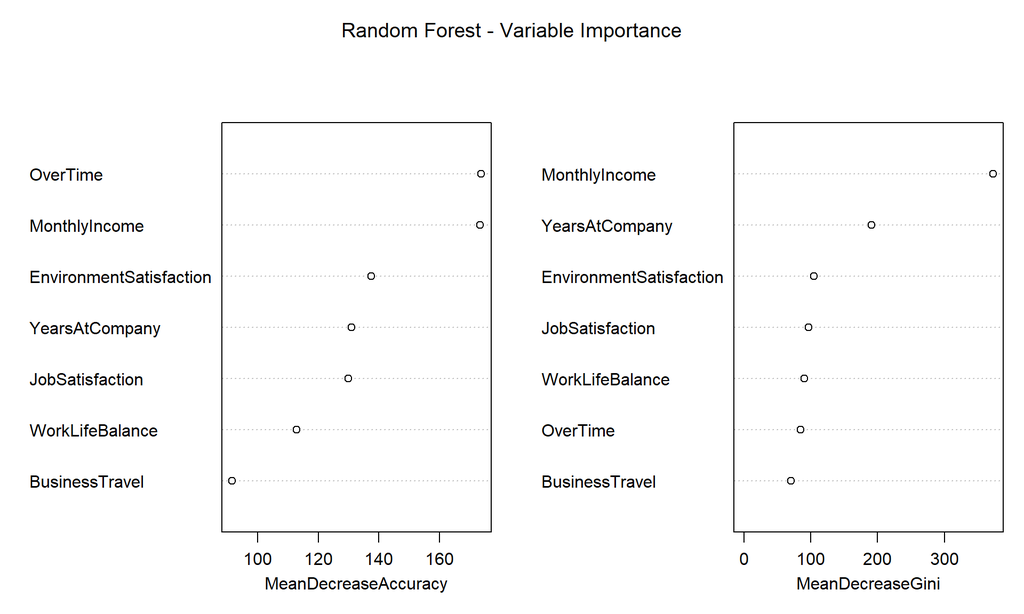

### 6.5 ROC Curve - Logistic Regression vs Random Forest

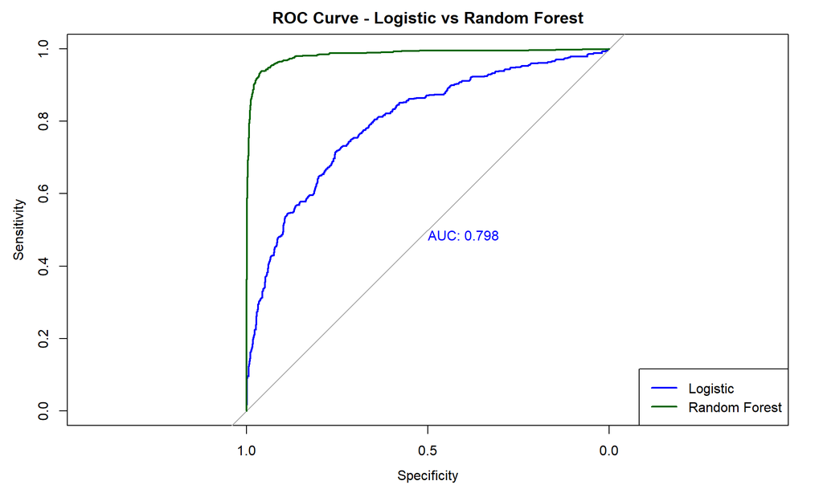

## 7 Clustering Analysis

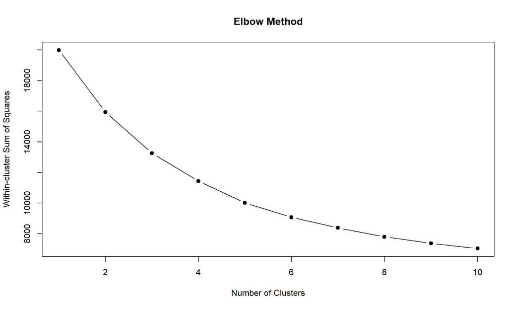

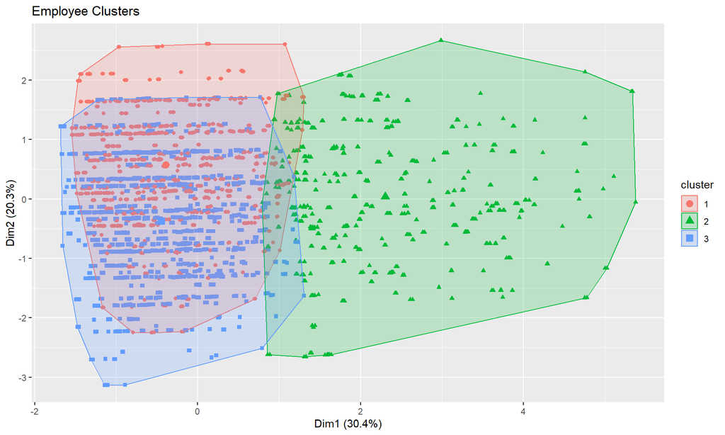

## 8 Conclusion & Recommendations

### 8.1 Interpretation of Statistical Results

- **Tenure:** t-tests confirm employees who left had significantly fewer years at the company (mean ~4.7 vs 7.3, p < 0.001).
- **Satisfaction:** Both job and environment satisfaction scores were lower for those who left (p < 0.001).
- **Income:** Monthly income was significantly lower for the attrition group (mean ~4600 vs 6800, p < 0.001).
- **OverTime:** Chi-square test shows a strong association between overtime and attrition (p < 0.001).
- **Job Role & Business Travel:** Chi-square tests show some roles and travel patterns are linked to higher attrition.

### 8.3 Final Summary

This project utilized EDA, hypothesis testing, and machine learning to understand employee turnover. Key drivers such as OverTime, job satisfaction, and tenure were found to be consistently significant.

Logistic regression helped quantify the effect of these features, while KMeans clustering provided segmentation insight useful for HR planning. These findings are directly tied to the SMART objectives defined at the outset.

### 8.4 SMART Recap Table

[output not shown]